# Clustering

Lesley Duff

2023-09-28

# Clustering

## Task 1

Do some exploratory analysis on the data. Comment on findings.

```r
library(broom)
library(factoextra)
library(tidyverse)
mall_customers <- read_csv("data/mall_customers.csv")
mall_customers <- mall_customers %>%
  janitor::clean_names()
```

```r
head(mall_customers)
```

| customer_id | gender | age | annual_income_k | spending_score_1_100 |
| --- | --- | --- | --- | --- |
| 1 | Male | 19 | 15 | 39 |
| 2 | Male | 21 | 15 | 81 |
| 3 | Female | 20 | 16 | 6 |
| 4 | Female | 23 | 16 | 77 |
| 5 | Female | 31 | 17 | 40 |
| 6 | Female | 22 | 17 | 76 |

```r
glimpse(mall_customers)
```

```
## Rows: 200
## Columns: 5
## $ customer_id          <dbl> 1, 2, 3, 4, 5, 6, 7, 8, 9, 10, 11, 12, 13, 14, 15…
## $ gender               <chr> "Male", "Male", "Female", "Female", "Female", "Fe…
## $ age                  <dbl> 19, 21, 20, 23, 31, 22, 35, 23, 64, 30, 67, 35, 5…
## $ annual_income_k      <dbl> 15, 15, 16, 16, 17, 17, 18, 18, 19, 19, 19, 19, 2…
## $ spending_score_1_100 <dbl> 39, 81, 6, 77, 40, 76, 6, 94, 3, 72, 14, 99, 15, …
```

```r
#skimr::skim(mall_customers) %>% View()
```

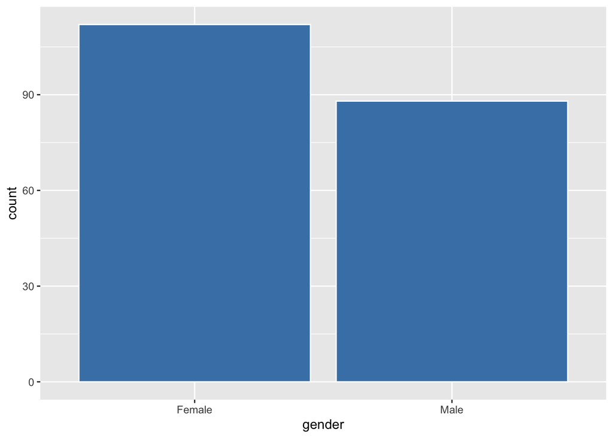

```r
mall_customers %>%
  ggplot(aes(x = gender)) +
  geom_bar(colour = "white", fill="steelblue")
```

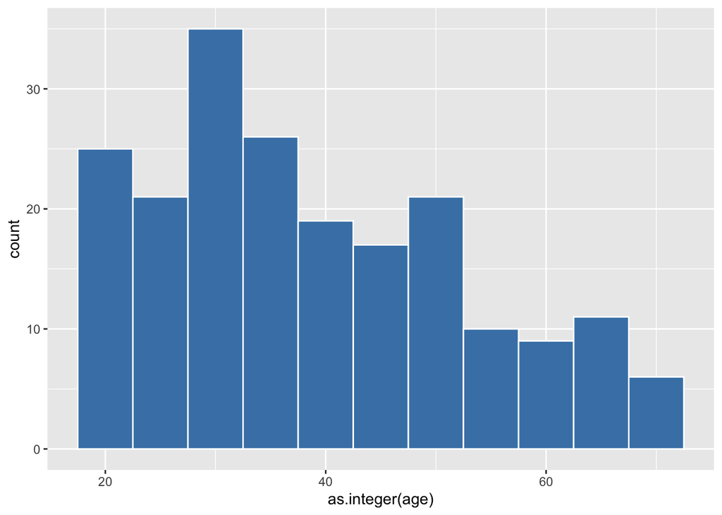

```r
mall_customers %>%
  ggplot(aes(x = as.integer(age))) +
  geom_histogram(binwidth = 5, colour = "white", fill="steelblue")
```

```r
age_stats <- mall_customers %>%
  summarise(min_age = min(age),
         max_age = max(age),
    mean_age = mean(age),
    annual_income_k = median(annual_income_k))
age_stats
```

| min_age | max_age | mean_age | annual_income_k |
| --- | --- | --- | --- |
| 18 | 70 | 38.85 | 61.5 |

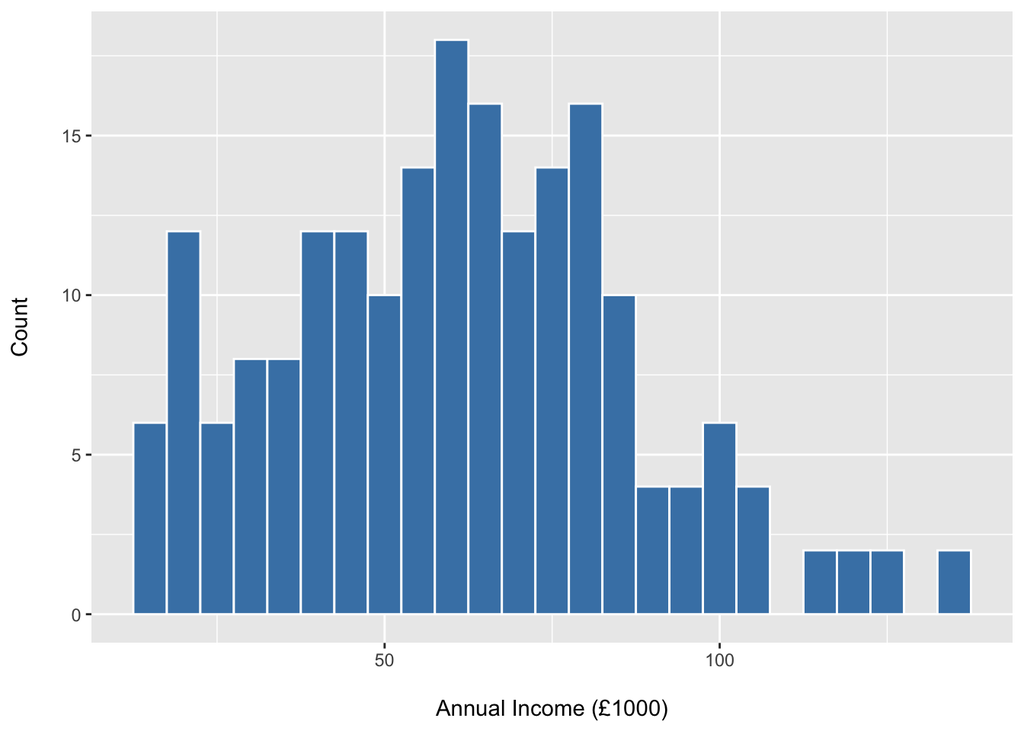

```r
mall_customers %>%
  ggplot(aes(x = as.integer(annual_income_k))) +
  geom_histogram(binwidth = 5, colour = "white", fill="steelblue")+
  labs(
    x = "\nAnnual Income (£1000)",
    y = "Count\n"
  )
```

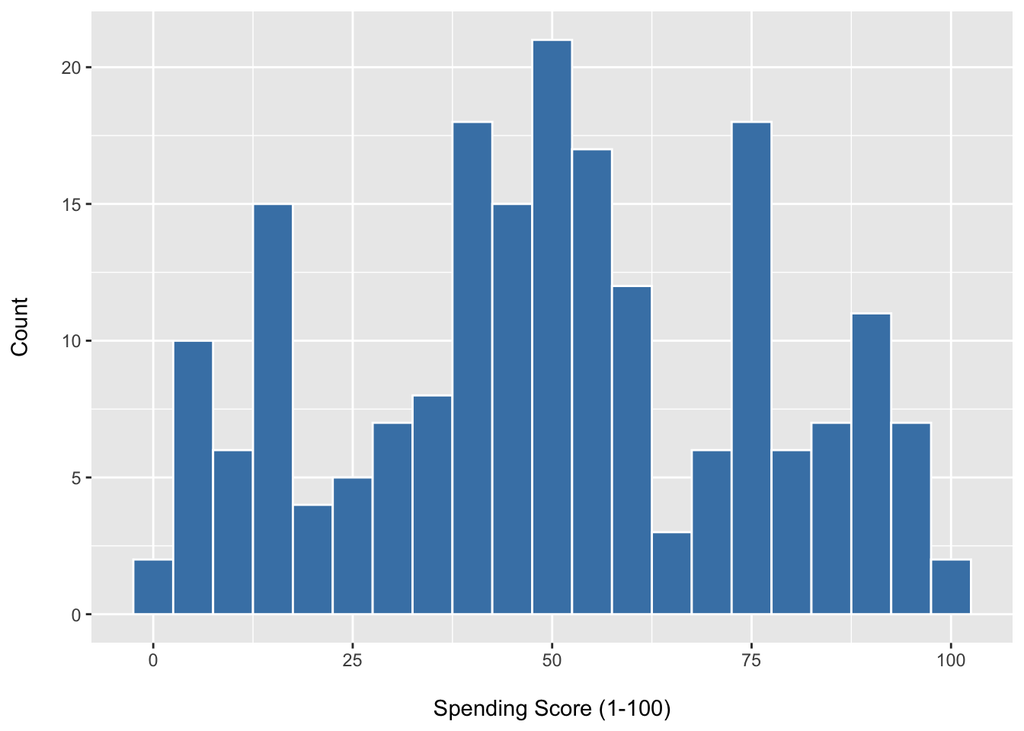

```r
mall_customers %>%
  ggplot(aes(x = spending_score_1_100)) +
  geom_histogram(binwidth = 5, colour = "white", fill="steelblue")+
  labs(
    x = "\nSpending Score (1-100)",
    y = "Count\n"
  )
```

From visualisation: Females outnumber males in terms of visitors to the mall. No children included Ages 18-70 with a mean of 38.85

## Task 2

We are interested in creating a marketing campaign to target customers based on their spending score and annual income. Select an appropriate value for k and perform k-means clustering to find if there are meaningful clusters in the data to target the customers.

```r
# spending score and annual income
mall_customers_spending_income <- mall_customers  %>%
    column_to_rownames("customer_id") %>%  # for plotting

              select(spending = spending_score_1_100,
                     income = annual_income_k)

head(mall_customers_spending_income)
```

|  | spending | income |
| --- | --- | --- |
| 1 | 39 | 15 |
| 2 | 81 | 15 |
| 3 | 6 | 16 |
| 4 | 77 | 16 |
| 5 | 40 | 17 |
| 6 | 76 | 17 |

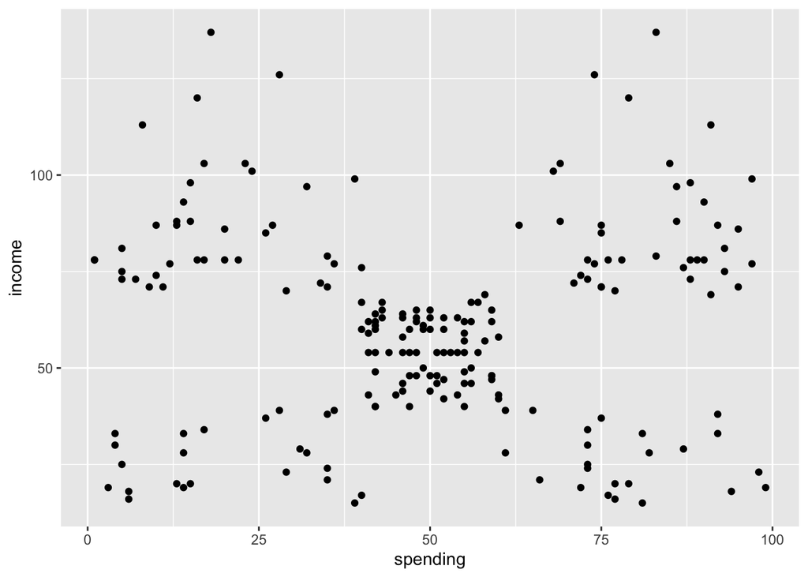

```r
mall_customers_spending_income %>%
  ggplot(aes(x = spending, y = income)) +
  geom_point()
```

Visually looks like roughly 5 clusters.

```r
# Scaling
mall_customers_spending_income_scale <- mall_customers_spending_income %>%
                mutate_if(is.numeric, scale)

mall_customers_spending_income_scale
```

|  | spending | income |
| --- | --- | --- |
| 1 | -0.433713114 | -1.73464625 |
| 2 | 1.192711064 | -1.73464625 |
| 3 | -1.711617825 | -1.69657236 |
| 4 | 1.037813523 | -1.69657236 |
| 5 | -0.394988729 | -1.65849848 |
| 6 | 0.999089138 | -1.65849848 |
| 7 | -1.711617825 | -1.62042459 |
| 8 | 1.696128071 | -1.62042459 |
| 9 | -1.827790981 | -1.58235070 |
| 10 | 0.844191597 | -1.58235070 |

[output cut: 190 more lines]

CHoose k

```r
# Set min & max number of clusters want to look at
max_k <- 20

k_clusters <- tibble(k = 1:max_k) %>%
  mutate(
    kclust = map(k, ~ kmeans(mall_customers_spending_income_scale,
                             .x, nstart = 25)),
    tidied = map(kclust, tidy),
    glanced = map(kclust, glance),
    augmented = map(kclust, augment, mall_customers_spending_income)
  )

k_clusters
```

| k | kclust | tidied | glanced | augmented |
| --- | --- | --- | --- | --- |
| 1 |  |  |  |  |
| 2 |  |  |  |  |
| 3 |  |  |  |  |
| 4 |  |  |  |  |
| 5 |  |  |  |  |
| 6 |  |  |  |  |
| 7 |  |  |  |  |
| 8 |  |  |  |  |
| 9 |  |  |  |  |
| 10 |  |  |  |  |

[output cut: 10 more lines]

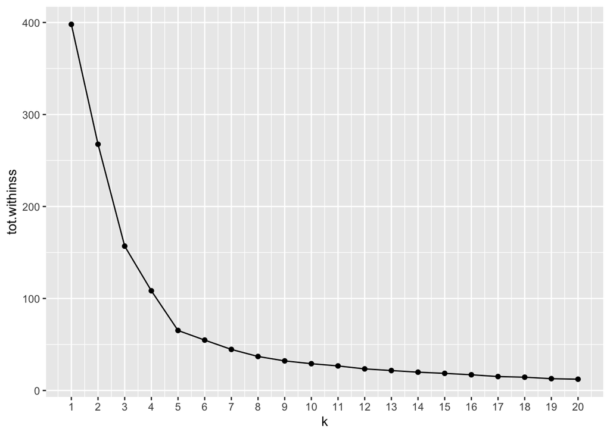

```r
clusterings <- k_clusters %>%
  unnest(glanced)

#clusterings

ggplot(clusterings, aes(x=k, y=tot.withinss)) +
  geom_point() +
    geom_line() +
    scale_x_continuous(breaks = seq(1, 20, by = 1))
```

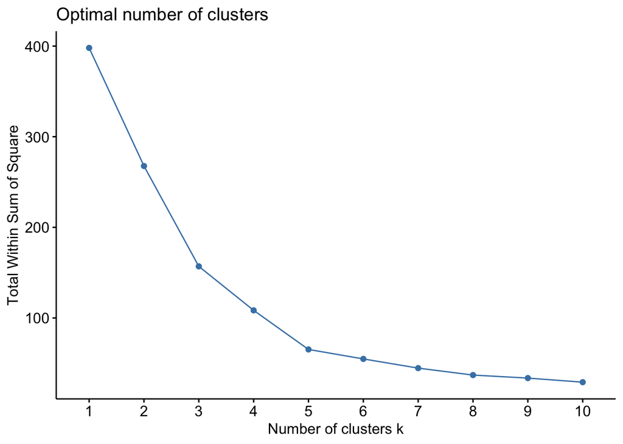

```r
fviz_nbclust(mall_customers_spending_income_scale,
             kmeans,
             method = "wss",
             nstart = 25)
```

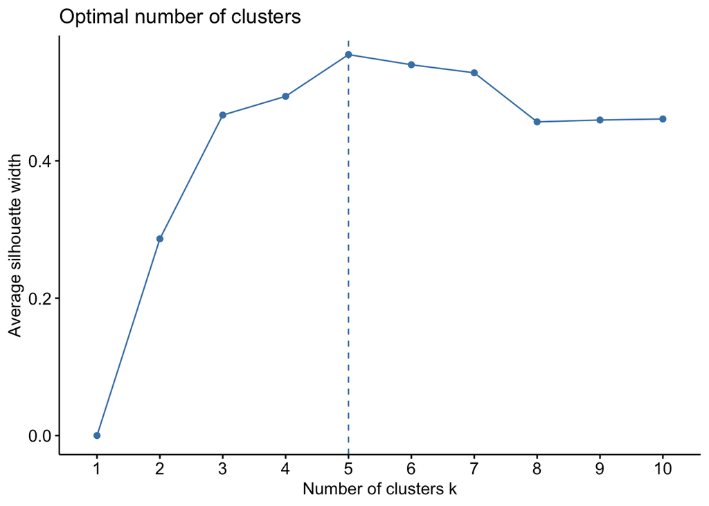

```r
fviz_nbclust(mall_customers_spending_income_scale,
             kmeans,
             method = "silhouette",
             nstart = 25)
```

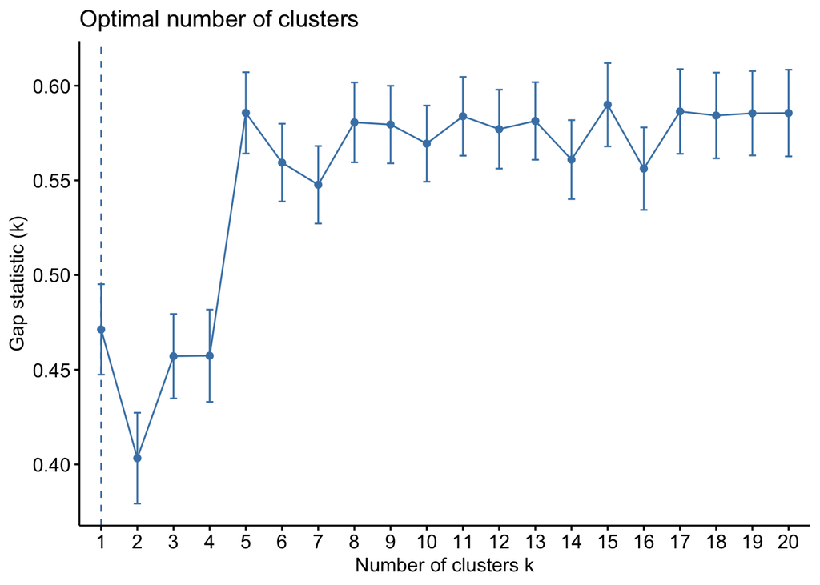

```r
fviz_nbclust(mall_customers_spending_income_scale,
             kmeans,
             method = "gap_stat",
             nstart = 25,
             k.max = 20)
```

I’m choosing k=5

Task 3

Visualise the clustering for your chosen value of k.

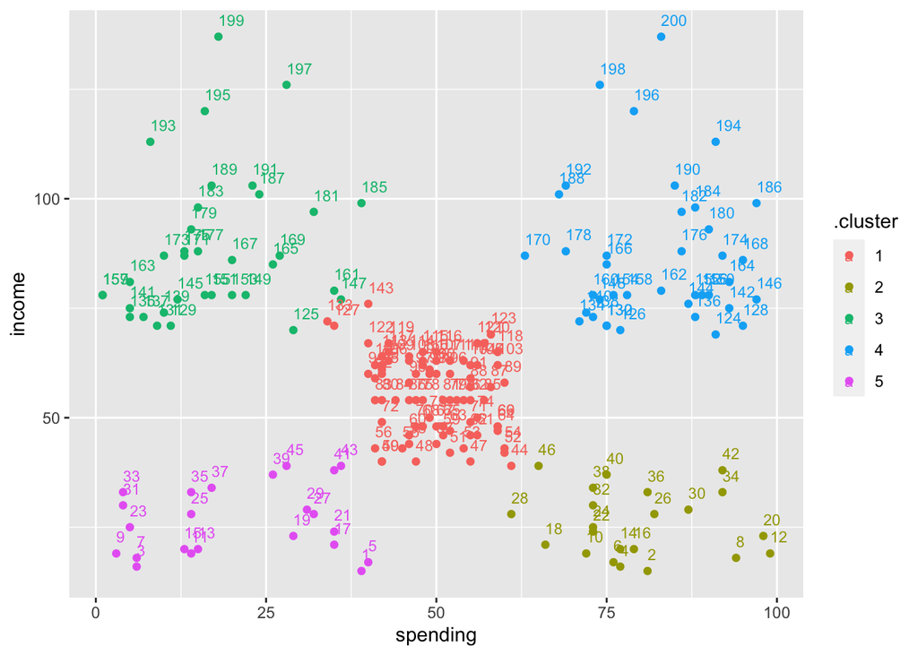

```r
 clusterings %>%
  unnest(cols = c(augmented)) %>%
  filter(k == 5) %>%
   ggplot(aes(x = spending, y = income, colour = .cluster, label = row.names(.))) +
  geom_point(aes(color = .cluster))+
  geom_text(hjust = -0, vjust = -1, size = 3)
```

```r
# David
#clusterings %>%
#  filter(k == 5) %>%
#  unnest(augmented) %>%
#  ggplot(aes(annual_income_k, spending_score_1_100, colour = .cluster)) +
#  geom_point() +
#  stat_ellipse(
#    aes(fill = .cluster),
#    geom = "polygon", alpha = 0.4, level = 0.95, linetype = 2,
#    show.legend = F
#  )
  # geom_point(data = centroids, aes(colour = cluster), size = 20, alpha = 0.25, show.legend = FALSE)
```

## Task 4

Do you think the clustering seems a good fit for this data?

Yes, clear separation of clusters.

## Task 5

Comment on the attributes of one or two of the clusters (maybe even give them an appropriate label if you like - similar to section 4.1 of the ‘ Segmentation & clustering intro’ lesson where we saw labels such as “Super Fans” and “Tag-Alongs”). I would need a better understanding of spending score. Need to go back to customer for clarification. I’m interpreting it as spending at this mall - higher meaning they purchase more at this particular mall.

3- Green - High income, Low spending These could be incentivised to spend more as they can afford it.